# Analysis of Gene Expression in 3T3-L1 Adipocytes

Innocence Harvey and Dave Bridges

2017-08-11

# Purpose

To determine the effects of adipocyte differentiation, and glucocorticoid treatment on *Pnpla2* gene expression in 3T3-L1 Cells

# Experimental Details

Cells were differentiated and treated with dexamethasone for a total of 15 days.

## Methods

- qPCR was performed as described in http://bridgeslab.sph.umich.edu/protocols/index.php?title=QPCR&oldid=1252

For qPCR the normalization gene was *Actb*.

# Raw Data

These data can be found in /Users/davebrid/Documents/GitHub/CushingAcromegalyStudy/scripts/scripts-obesity in a file named ../../data/raw/3T3-L1 Gene Expression Summary.csv. This script was most recently updated on Fri Aug 11 10:01:53 2017.

# Analysis

These are the summary *Pnpla2* levels from 2 independent experiments.

## Normalized Values

We normalized each experiment such that the mature adipocytes Pnpla2 levels were equal to one.

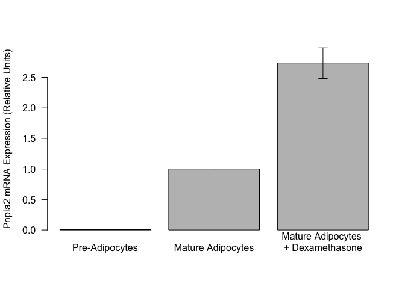

## Statistics

We observed a **2.735** fold increase in *Pnpla2* with dexamethasone.

For the normalized data, we did a Shapiro-Wilk test on the Mature Adipocytes with Dexamethasone group. This had a p-value of 0.169 so normality could be assumed. We therefore did a one-way *t*-test which yielded a p-value of **0.002**.

In terms of the pre-adipocytes, we observed a **99.46%** decrease in Pnpla2 in the. For this, we did a Shapiro-Wilk test on the Pre-Adipocytes group. For the pre-adipocyte group there was only an n of 2 so normality was assumed. We did a one-way *t*-test which yielded a p-value of **0**.

# Interpretation

Both differentiation and dexamethasone increased *Pnpla2* expression